# Bayesian Modeling of Plant Edibility

# Introduction

How many of the estimated 342,000 to 369,000 known vascular plant species are edible? Estimates vary wildly, with some suggesting fewer than 10,000 edible species, while others estimate as many as 30,000. This uncertainty reflects the complexity of defining edibility, influenced by cultural practices, biological factors, and processing requirements. Here we assess sampling uncertainty to determine how much data is needed before we can make reliable inferences about an entire population. We apply logic to plant edibility. We aim to estimate the true proportion of edible plant species using Bayesian inference and random sampling. Our approach incorporates different definitions of edibility and considers cultural practices and processing requirements.

This analysis tests the assumptions about plant edibility using three definitions:

1. **Raw Edibility**: Whole plant edible raw (e.g., *Brassica oleracea*).
2. **Partial Edibility**: Parts of the plant are edible (e.g., apples).
3. **Processed Edibility**: Toxic unless processed (e.g., *Solanaceae* spp. or oak).

We use a **Bayesian hierarchical model** to assess the likelihood of species being edible under these definitions, accounting for ethnobotanical evidence, toxicity, and processing requirements.

# Methods

## Defining Edibility Criteria

Each species is assessed based on:

- **Number of Ethnobotanical Reports**: Proxy for evidence strength.
- **Toxicity Evidence**: Binary indicator (1 = toxic, 0 = non-toxic).
- **Processing Requirement**: Categorical (raw, cooked, processed).
- **Edibility Outcome**: Binary (1 = edible, 0 = non-edible).

## Data Simulation and Sampling Strategy

To estimate the proportion of edible plants, we simulate a dataset of 200 species and implement a Beta-Binomial Bayesian model. The true proportion of edible plants remains unknown but is inferred based on random samples.

```r
# Load the dataset
set.seed(42)  # Set random seed for reproducibility
species_data <- read.csv("data/randomsample200species_and_synonims.csv")
```

Assign edibility randomly for now

```r
# Assign random edibility status (20% edible, 80% non-edible)
species_data$edibility <- sample(c(0, 1), size = nrow(species_data), replace = TRUE, prob = c(0.8, 0.2))
```

Convert dataset into model-ready format and add random data for now

```r
n_species <- nrow(species_data)
data <- species_data %>%
  mutate(
    reported_edibility = sample(c("Raw", "Partial", "Processed"), n_species, replace = TRUE),
    ethnobotanical_reports = rpois(n_species, lambda = 3),
    toxicity = rbinom(n_species, 1, 0.3),
    processing_level = sample(c("None", "Cooked", "Processed"), n_species, replace = TRUE)
  )
```

## Bayesian Model Specification and Posterior Inference

This analysis utilizes several R packages for modeling and visualization. Specifically, we employ `brms` for Bayesian modeling (Bürkner (2024)), `bayesplot` for diagnostic visualization (Gabry and Mahr (2024)), `tidyverse` for data manipulation (Wickham (2023)), and `HDInterval` for computing highest density intervals (Meredith and Kruschke (2022)). These packages provide robust tools for implementing Bayesian hierarchical models and interpreting the resulting posterior distributions.

```r
# Fit a Bayesian logistic regression model
# This model estimates the probability of a species being edible based on key predictors.

# Fit Bayesian logistic regression model using the brms package
# The response variable 'edibility' is modeled as a function of:
# - reported_edibility: the category of edibility (Raw, Partial, Processed)
# - ethnobotanical_reports: number of reports indicating use
# - toxicity: binary indicator (1 = toxic, 0 = non-toxic)
# - processing_level: level of processing required to make edible
# - Random effect for scientificName to account for unobserved variability across species
edibility_model <- brm(
  edibility ~ reported_edibility + ethnobotanical_reports + toxicity + processing_level + (1 | scientificName),
  data = data,  # Data being modeled
  family = bernoulli(),  # Logistic regression model for binary outcome
  prior = c(
    set_prior("normal(0, 1)", class = "b"),  # Weakly informative priors for coefficients
    set_prior("normal(0, 5)", class = "Intercept")  # Prior for model intercept
  ),
  chains = 4,  # Number of Markov chains to run
  cores = 4,  # Number of CPU cores to use for parallel computation
  iter = 5000  # Total number of iterations per chain
)
```

[output not shown]

### Perform Beta-Binomial estimation for the overall edibility proportion

```r
# Set prior values for the Beta distribution (weakly informative prior) given that existing literature suggests 7,000 to 30,000 edible species
alpha_prior <- 1; beta_prior <- 1   # Uniform (flat prior, all proportions equally likely)
alpha_prior <- 10; beta_prior <- 90 # Weakly informative, reflecting existing estimates (10% edible)

# Calculate the total number of observed edible species and total species in the sample
# This helps update our prior beliefs based on the observed data
total_edible <- sum(data$edibility)  # Sum of edible species in the dataset
total_species <- n_species  # Total number of species sampled

# Update the posterior distribution parameters based on observed data
# The posterior parameters are simply the prior values updated with the new data
alpha_post <- alpha_prior + total_edible  # Update 'successes'
beta_post <- beta_prior + total_species - total_edible  # Update 'failures'
```

Calculate the credible interval and mean estimate for the posterior with the `HDInterval` package to compute the 95% highest density interval (HDI) (Meredith and Kruschke (2022)).

```r
credible_interval <- HDInterval::hdi(rbeta(10000, alpha_post, beta_post), credMass = 0.95)  # Simulate draws from posterior

# Display the mean estimate and credible interval for the proportion of edible species
list(
  mean_estimate = alpha_post / (alpha_post + beta_post),  # Mean estimate of the proportion of edible plants
  credible_interval = credible_interval  # 95% credible interval around the mean estimate
)
```

```
## $mean_estimate
## [1] 0.1666667
##
## $credible_interval
##     lower     upper
## 0.1274179 0.2108307
## attr(,"credMass")
## [1] 0.95
```

# Results

## Estimating the Percentage of Edible Species

To provide a meaningful estimate of the total number of edible plant species, we apply the posterior mean and credible intervals to the estimated range of known vascular plants (342,000 to 369,000 species). This approach reflects the inherent uncertainty in both the total number of species and the proportion that may be edible.

## Estimating the Total Number and Percentage of Edible Species

Before calculating the final percentage and total edible species, we need to apply the posterior mean and credible intervals to the estimated range of known vascular plants (342,000 to 369,000). This ensures that variables like `mean_proportion` and `credible_bounds` are correctly defined before use.

```r
# Calculate the expected number of species based on the posterior estimate
# uses the posterior mean proportion of edible species and applies it to the total estimated number of vascular plants (342,000 to 369,000 species)
lower_bound_species <- 342000  # Lower bound for total species count
upper_bound_species <- 369000  # Upper bound for total species count

# # Calculate the expected mean proportion of edible species from posterior parameters
mean_proportion <- alpha_post / (alpha_post + beta_post)
# # Compute expected number of edible species based on this proportion
# expected_edible_lower <- mean_proportion * lower_bound_species
# expected_edible_upper <- mean_proportion * upper_bound_species

credible_bounds <- credible_interval  # 95% credible interval from posterior

# Compute expected edible species counts for both ends of the range
expected_edible_lower <- credible_bounds[1] * lower_bound_species
expected_edible_upper <- credible_bounds[2] * upper_bound_species

# Compute credible intervals for the lower and upper bounds
credible_lower_lower <- credible_bounds[1] * lower_bound_species
credible_lower_upper <- credible_bounds[2] * lower_bound_species
credible_upper_lower <- credible_bounds[1] * upper_bound_species
credible_upper_upper <- credible_bounds[2] * upper_bound_species
```

To finalize the analysis, we calculate both the estimated percentage of edible species and the total number of edible vascular plants, using the range of total species (342,000 to 369,000). This provides a comprehensive view of how the proportion translates into absolute numbers across the plausible range of known species.

### Calculate the overall percentage of edible species

```r
# Calculate the overall percentage of edible species
# This converts the proportion of edible species from the Bayesian model into a percentage.
# We also calculate the 95% credible interval, which shows the range where we believe the true percentage likely falls.
# Calculate overall percentages and total numbers
mean_percentage <- mean_proportion * 100
credible_percentage_lower <- credible_bounds[1] * 100
credible_percentage_upper <- credible_bounds[2] * 100

# Display the results
list(
  mean_percentage_edible = mean_percentage,
  credible_interval_percentage = c(credible_percentage_lower, credible_percentage_upper),
  total_edible_species_range = c(expected_edible_lower, expected_edible_upper),
  credible_edible_species_lower = c(credible_lower_lower, credible_lower_upper),
  credible_edible_species_upper = c(credible_upper_lower, credible_upper_upper)
)
```

```
## $mean_percentage_edible
## [1] 16.66667
##
## $credible_interval_percentage
##    lower    upper
## 12.74179 21.08307
##
## $total_edible_species_range
##    lower    upper
## 43576.91 77796.51
##
## $credible_edible_species_lower
##    lower    upper
## 43576.91 72104.09
##
## $credible_edible_species_upper
##    lower    upper
## 47017.19 77796.51
```

## Estimating the Percentage of Edible Species

To provide a meaningful estimate of the total number of edible plant species, we apply the posterior mean and credible intervals to the estimated range of known vascular plants (342,000 to 369,000 species). This approach reflects the inherent uncertainty in both the total number of species and the proportion that may be edible.

## Model Summary

```r
# Summarize the fitted Bayesian model
# This output provides key information about the estimated effects of each factor on plant edibility.
summary(edibility_model)
```

```
##  Family: bernoulli
##   Links: mu = logit
## Formula: edibility ~ reported_edibility + ethnobotanical_reports + toxicity + processing_level + (1 | scientificName)
##    Data: data (Number of observations: 200)
##   Draws: 4 chains, each with iter = 5000; warmup = 2500; thin = 1;
##          total post-warmup draws = 10000
##
## Multilevel Hyperparameters:
## ~scientificName (Number of levels: 200)
##               Estimate Est.Error l-95% CI u-95% CI Rhat Bulk_ESS Tail_ESS
## sd(Intercept)     5.92      2.93     1.45    12.76 1.00      990      921
##
## Regression Coefficients:
##                             Estimate Est.Error l-95% CI u-95% CI Rhat Bulk_ESS
## Intercept                      -4.92      2.50   -10.93    -1.27 1.00     1471
## reported_edibilityProcessed    -0.33      0.80    -1.92     1.26 1.00    10002
## reported_edibilityRaw           0.30      0.78    -1.24     1.79 1.00     9198
## ethnobotanical_reports         -0.09      0.37    -0.89     0.64 1.00     5206
## toxicity                        0.60      0.77    -0.96     2.12 1.00     8426
## processing_levelNone           -0.34      0.79    -1.86     1.23 1.00     8706
## processing_levelProcessed      -0.27      0.80    -1.83     1.33 1.00     9021
##                             Tail_ESS
## Intercept                       2417
## reported_edibilityProcessed     6509
## reported_edibilityRaw           6472
## ethnobotanical_reports          4033
## toxicity                        7488
## processing_levelNone            7344
## processing_levelProcessed       6943
##
## Draws were sampled using sampling(NUTS). For each parameter, Bulk_ESS
## and Tail_ESS are effective sample size measures, and Rhat is the potential
## scale reduction factor on split chains (at convergence, Rhat = 1).
```

## Posterior Predictive Checks

In the context of the `pp_check()` function from the `bayesplot` package, two key elements are compared:

- **Observed Data (`y`)**: This represents the actual recorded data from the sample, where each value corresponds to whether a species is considered edible (1) or non-edible (0).
- **Simulated Data (`yrep`)**: This consists of multiple datasets simulated from the posterior predictive distribution of the fitted model. These simulated datasets reflect what the model predicts the data should look like if it accurately represents the underlying data-generating process.

In the generated plot:

- The **x-axis** represents the outcome variable of interest, such as the proportion or count of edible species.
- The **y-axis** shows the density or frequency of occurrences in the simulated datasets.

If the observed data aligns well with the simulated predictions, the model can be considered a good fit. Significant deviations between the observed data and the simulated predictions suggest the model might not be capturing important relationships in the data.

`pp_check` from the Gabry and Mahr (2024) package generates a posterior predictive check plot. This diagnostic tool compares the observed data with data simulated from the posterior predictive distribution. It helps assess whether our Bayesian model adequately captures the patterns in the actual data.

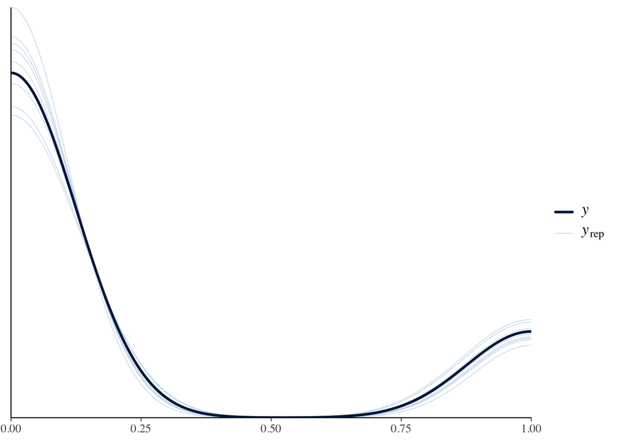

```r
# STEP 6: Perform posterior predictive checks
# This diagnostic assesses whether the Bayesian model adequately fits the data.
bayesplot::pp_check(edibility_model)  # This generates a posterior predictive check plot.
```

```r
# The observed data is shown as a line or histogram, representing the actual distribution of edible species in your sample.
# Simulated data from the model (posterior predictions) are overlaid as density plots or histograms.
# If the observed data aligns well with the simulated predictions, this indicates the model fits the data well.
# Significant deviations suggest the model might be missing important factors or relationships.
```

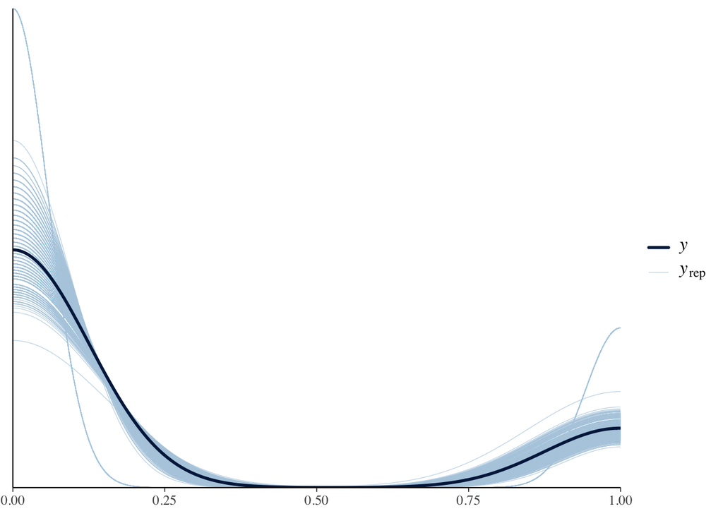

```r
# Compare Observed vs. Predicted Data
ppc_dens_overlay(y = data$edibility, yrep = posterior_predict(edibility_model, draws = 100))
```

### Alternative predictors

```r
edibility ~ reported_edibility * toxicity + (1 | scientificName)
```

```
## edibility ~ reported_edibility * toxicity + (1 | scientificName)
```

Observed data is shown as a line
$$y$$
representing the actual distribution of edible species in the sample. Simulated data from the model (posterior predictions) are overlaid as density plots or histograms
$$yrep$$

## Posterior Distributions

Visualizing the effect of edibility reports with thge `marginal_effects()` function in `brms`. The plots show how the predictor variables affect the outcome based on the posterior distribution of the Bayesian model (Bürkner (2024)).

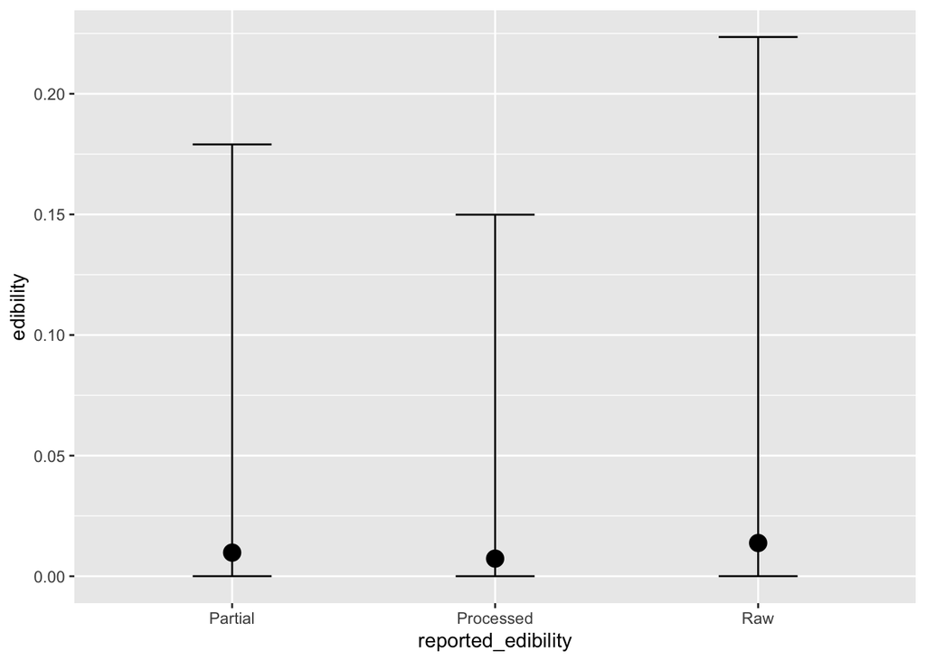

```r
# Visualize posterior distributions
# These plots show how edibility reports and toxicity affect the probability of a plant being edible.
plot(marginal_effects(edibility_model, effects = "reported_edibility"))
```

Visualizing the effect of toxicity:

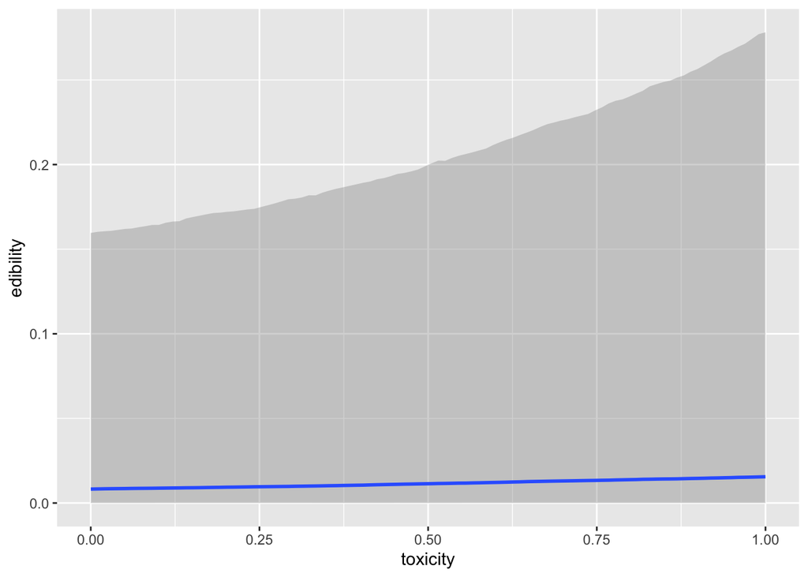

```r
plot(marginal_effects(edibility_model, effects = "toxicity"))
```

# Discussion

## Final Estimate of Edible Species

The Bayesian analysis estimates that approximately:

```r
# This step outputs:
# - The estimated percentage of edible species
# - The credible interval for that percentage
# - The estimated number of edible species across the full range of known vascular plants
# Display final estimates clearly
cat(sprintf("Estimated percentage of edible vascular plant species: %.2f%%, with 95%% credible interval ranging from %.2f%% to %.2f%%. This range reflects substantial uncertainty in the true proportion.",
            mean_percentage, credible_percentage_lower, credible_percentage_upper))
```

```
## Estimated percentage of edible vascular plant species: 16.67%, with 95% credible interval ranging from 12.74% to 21.08%. This range reflects substantial uncertainty in the true proportion.
```

Total number of edible plants

```r
cat(sprintf(". Estimated total number of edible vascular plant species: %.0f to %.0f (95%% CI: %.0f - %.0f for 342,000 species; %.0f - %.0f for 369,000 species).",
            expected_edible_lower, expected_edible_upper,
            credible_lower_lower, credible_lower_upper,
            credible_upper_lower, credible_upper_upper))
```

```
## . Estimated total number of edible vascular plant species: 43577 to 77797 (95% CI: 43577 - 72104 for 342,000 species; 47017 - 77797 for 369,000 species).
```

# Conclusion

Using Bayesian hierarchical modeling, we can rigorously test how different definitions of edibility affect our understanding of the edible plant species pool, while incorporating uncertainty and prior evidence.

# References

Bürkner, Paul-Christian. 2024. *Brms: Bayesian Regression Models Using Stan*. https://github.com/paul-buerkner/brms.

Gabry, Jonah, and Tristan Mahr. 2024. *Bayesplot: Plotting for Bayesian Models*. https://mc-stan.org/bayesplot/.

Meredith, Mike, and John Kruschke. 2022. *HDInterval: Highest (Posterior) Density Intervals*. https://CRAN.R-project.org/package=HDInterval.

Wickham, Hadley. 2023. *Tidyverse: Easily Install and Load the Tidyverse*. https://tidyverse.tidyverse.org.